# Automatic v. Manual Transmission MPG Study

Paul Cappa

December 18, 2015

# Synopsis

Looking at a data set of a collection of cars, we is interested in exploring the relationship between a set of variables and miles per gallon (MPG) (outcome). We are particularly interested in the following two questions:

1. Is an automatic or manual transmission better for MPG?
2. “Quantify the MPG difference between automatic and manual transmissions”?

# Preparing the Data for the Analysis

The first step in the anlysis is to prepare the data. The sub-steps performed are as follows:

1. Load the **‘mtcars’** dataset.
2. Remove the **‘qsec’** variable (qsec is the 1/4 mile time and is irrelevant to this analysis).
3. Convert key variables into factors. Note: Renaming the variable **‘am’** factors to ‘Auto’ and ‘Man’ will make plots much more intuitive (versus ‘0’ and ‘1’). Also, renaming the variable **‘vs’** factors to ‘V’ and ‘S’ are done for the same reason (should we need them).
4. The remaining variables are continuous and therefore are not converted to factors.

```r
data(mtcars)                                                # Load the dataset
mtcars <- mtcars[, c(1:6,8:11)]                             # Remove the 'qsec' variable.
mtcars$am   <- factor(mtcars$am,labels=c("Auto","Man"))     # Factor 'am' to 'Auto' and 'Man'
mtcars$cyl  <- factor(mtcars$cyl)                           # Convert cylinders to a factor.
mtcars$vs   <- factor(mtcars$vs, labels=c("V", "S"))        # Factor the engine type to 'V' and 'S'
mtcars$gear <- factor(mtcars$gear)                          # Convert the number of gears to a factor.
mtcars$carb <- factor(mtcars$carb)                          # Convert the number of carburators to a factor.
str(mtcars)
```

```
## 'data.frame':    32 obs. of  10 variables:
##  $ mpg : num  21 21 22.8 21.4 18.7 18.1 14.3 24.4 22.8 19.2 ...
##  $ cyl : Factor w/ 3 levels "4","6","8": 2 2 1 2 3 2 3 1 1 2 ...
##  $ disp: num  160 160 108 258 360 ...
##  $ hp  : num  110 110 93 110 175 105 245 62 95 123 ...
##  $ drat: num  3.9 3.9 3.85 3.08 3.15 2.76 3.21 3.69 3.92 3.92 ...
##  $ wt  : num  2.62 2.88 2.32 3.21 3.44 ...
##  $ vs  : Factor w/ 2 levels "V","S": 1 1 2 2 1 2 1 2 2 2 ...
##  $ am  : Factor w/ 2 levels "Auto","Man": 2 2 2 1 1 1 1 1 1 1 ...
##  $ gear: Factor w/ 3 levels "3","4","5": 2 2 2 1 1 1 1 2 2 2 ...
##  $ carb: Factor w/ 6 levels "1","2","3","4",..: 4 4 1 1 2 1 4 2 2 4 ...
```

# Exploratory Data Analysis

Next, we take a preliminary look at the data. This will be performed with the following sub-steps.

### Comparison of the Means

```r
paste0("Auto Mean = ", round(mean(mtcars$mpg[mtcars$am=="Auto"]),2),
    ", Man Mean = ", round(mean(mtcars$mpg[mtcars$am=="Man"]),2))
```

```
## [1] "Auto Mean = 17.15, Man Mean = 24.39"
```

# Statistical Inference

The null hypothesis is that the manual and automatic transmissions are represeted by the same distribution. The assumption is that the sample, represented within the **‘mtcars’** data set is representative of the total population of vehicles.

```r
t <- t.test(mpg ~ am, data = mtcars)
t$p.value
```

```
## [1] 0.001373638
```

With a p-value of .001373638, we can comfortably reject the null hypothesis and say the manual and automatic transmission data are from different distributions.

# Regression Analysis

The regression analysis will happen in the following sub-steps:

1. Fit the full model.
2. Step through the full model to find the best fit.

```r
fit <- lm(mpg ~ ., data = mtcars)                       # Fit the full model
best <- step(fit, direction = "both", trace=FALSE)      # Find the step model.
summary(best)
```

```
##
## Call:
## lm(formula = mpg ~ cyl + hp + wt + am, data = mtcars)
##
## Residuals:
##     Min      1Q  Median      3Q     Max
## -3.9387 -1.2560 -0.4013  1.1253  5.0513
##
## Coefficients:
##             Estimate Std. Error t value Pr(>|t|)
## (Intercept) 33.70832    2.60489  12.940 7.73e-13 ***
## cyl6        -3.03134    1.40728  -2.154  0.04068 *
## cyl8        -2.16368    2.28425  -0.947  0.35225
## hp          -0.03211    0.01369  -2.345  0.02693 *
## wt          -2.49683    0.88559  -2.819  0.00908 **
## amMan        1.80921    1.39630   1.296  0.20646
## ---
## Signif. codes:  0 '***' 0.001 '**' 0.01 '*' 0.05 '.' 0.1 ' ' 1
##
## Residual standard error: 2.41 on 26 degrees of freedom
## Multiple R-squared:  0.8659, Adjusted R-squared:  0.8401
## F-statistic: 33.57 on 5 and 26 DF,  p-value: 1.506e-10
```

# Residuals

The final step in the analysis is to review the Residuals (See: Appendix, Figure 3).

# Appendix - Supporting Figures

### Figure 1 - Side by Side Comparison of Manual and Automatic Transmissions

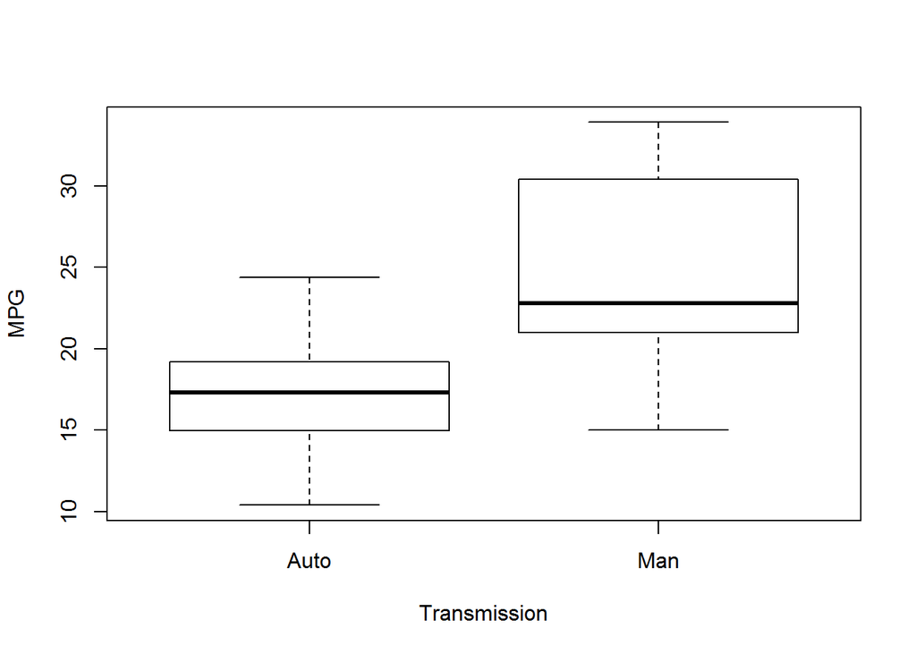

### Figure 2 - Examining Potential Correlation MPG and Other Factors

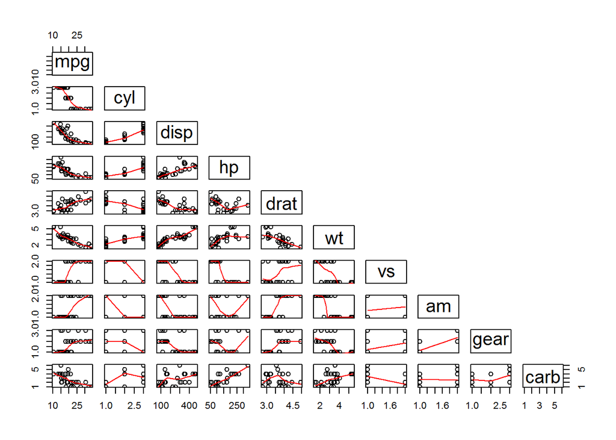

### Figure 3 - Residuals and Diagnostic Plots

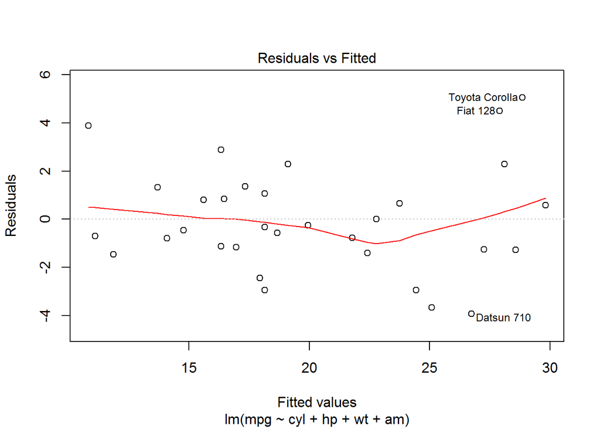

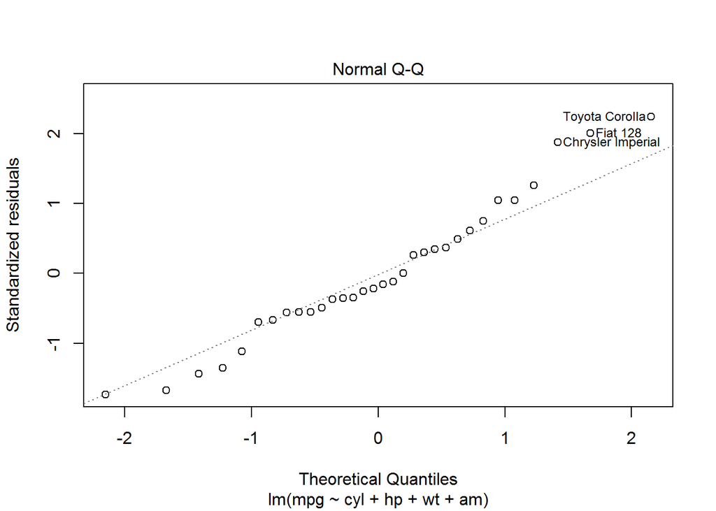

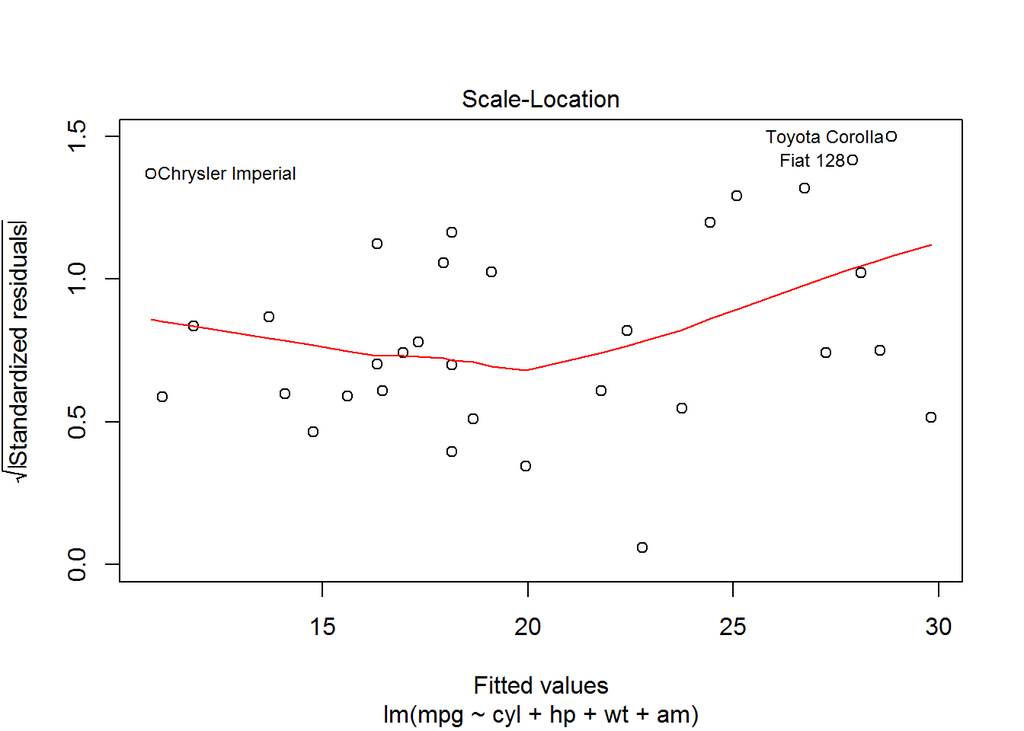

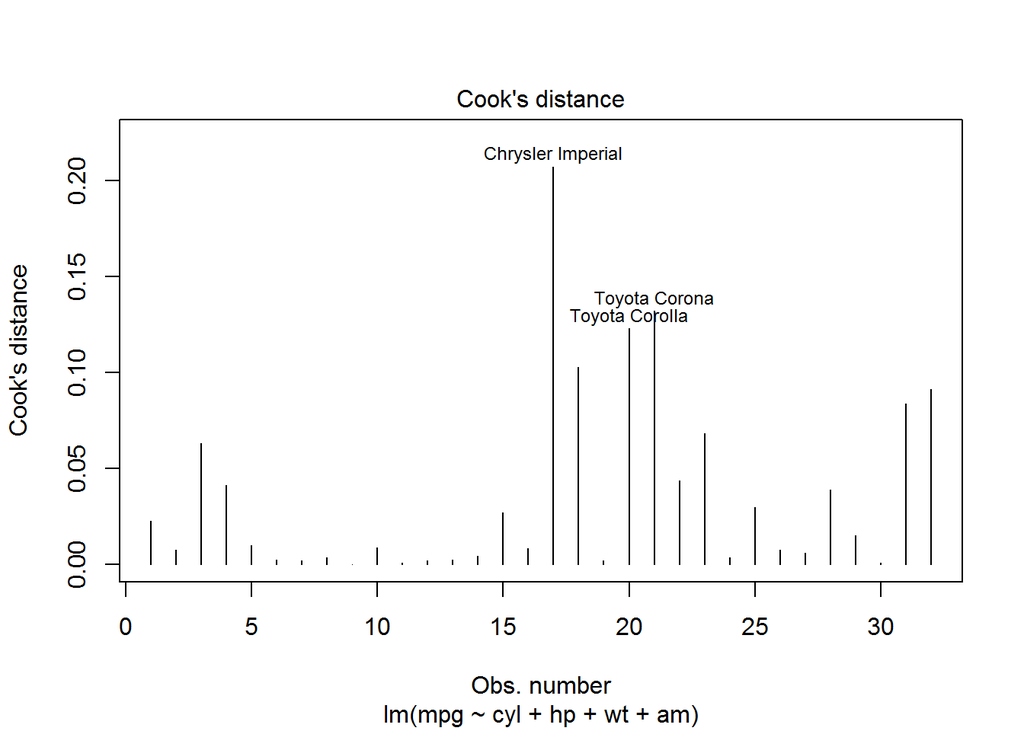